## Data

This Markdown is used in conjunction with the dataset: “palmerpenguins”, whcih includes two sub-datasets. Both datasets contain data for 344 penguins. There are 3 different species of penguins in this dataset, collected from 3 islands in the Palmer Archipelago, Antarctica. `species`, `bill_length_mm`, `bill_depth_mm`, `flipper_length_mm`, `body_mass_g`, `sex` and `year` are the variables included.

## Single trait distribution

### What is the lowest and highest bill lengths do penguins in this dataset have?

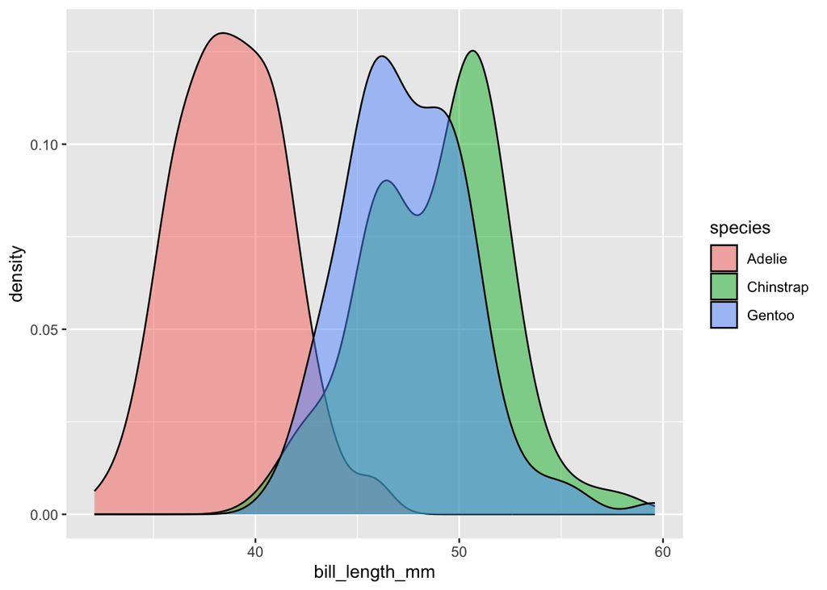

*The lowest bill length is 32.10 mm and the highest bill length is 59.60 mm.*

### Do different species have different bill lengths? How much do they overlap?

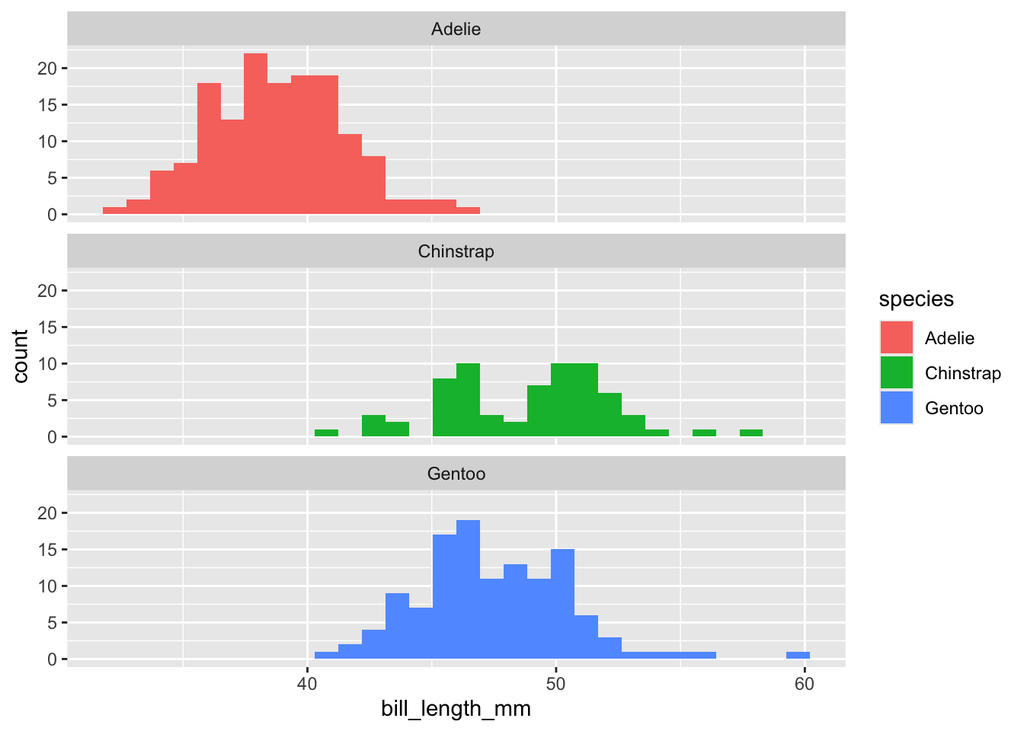

*Bill length differs by species, `Gentoo` and `Chinstrap` having the largest and `Adelie` having the smallest.`Gentoo` and `Chinstrap` have very similar bill lengths, ranging from ~40 mm to ~60 mm.*

## Relationship between multiple traits

### What is the relationship between body mass and flipper length in penguins in this dataset?

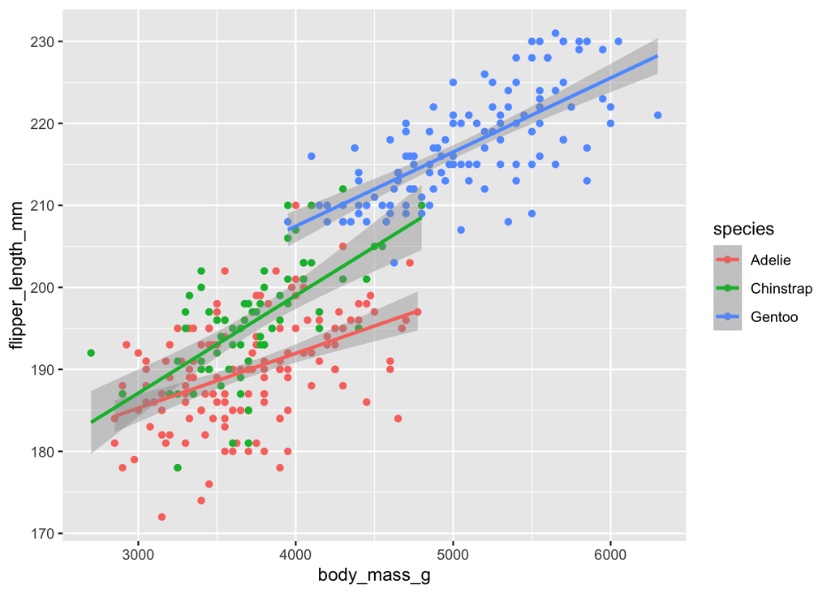

*Flipper length increases with body mass. There is a postive relationship between body mass and flipper length.*

### Does this relationship differ between species?

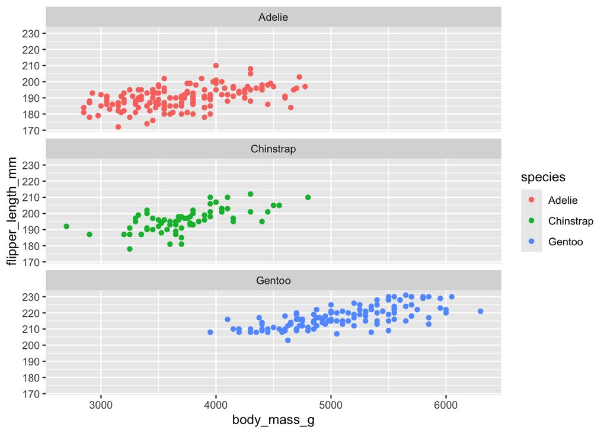

*Flipper length displays a slight upward trend as body mass increases in all penguin species.*

### Given the same body mass, which species of penguins tend to have the longest flippers?

*Gentoo penguin species tend to have longer flippers on average.*

## Sexual dimorphism

### What traits are sexually dimorphic in the penguins dataset?

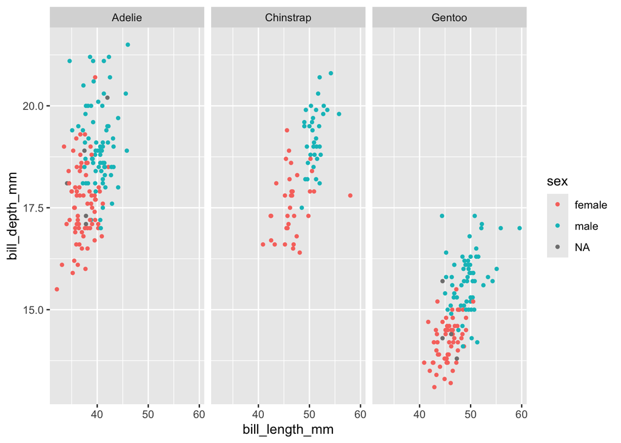

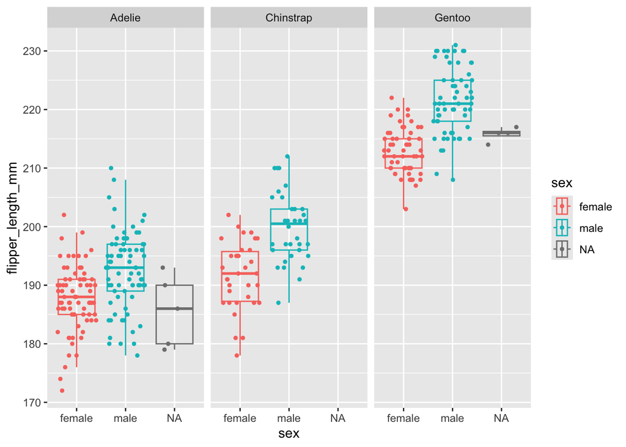

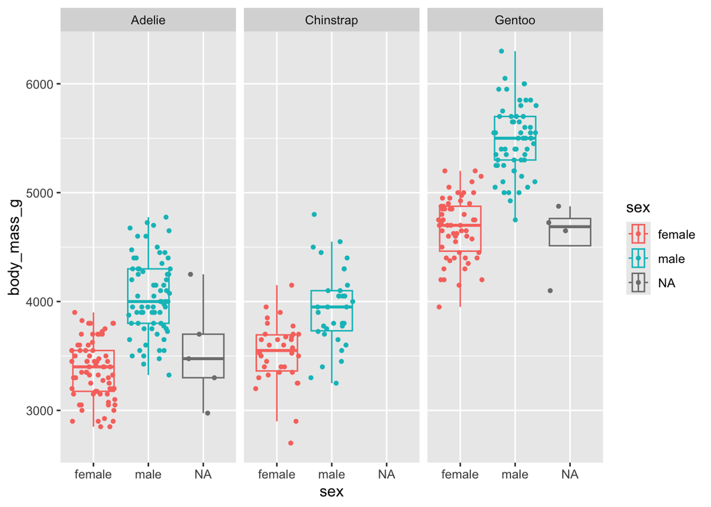

*Bill length : bill depth, flipper length and body mass are all sexually dimorphic across species. Males have larger averages in all three indices across all three species.*